# Data wrangling

Paul M. Magwene

# Real-world data is often messy

Data files you generate or will be given may…

- Be poorly organized
- Have missing values
- Contain extraneous information
- Confounds variables and labels

# Tidy data

To facilitate downstream analyses, data should be organized in a manner such that…

1. Each variable must have its own column.
2. Each observation must have its own row.
3. Each value must have its own cell.

# tidyr and dplyr provide powerful functions for data wrangling

Both `dplyr` and `tidyr` are loaded when we load the `tidyverse` metapackage:

```r
library(tidyverse)
```

# Example: Starting messy data

```
# Generated by Alexa and Brandon
,DrugX_low,DrugX_high,,DrugY_low_rep1,DrugY_low_rep2,DrugY_high_rep1,DrugY_high_rep2
GeneA,0.15,,,-0.15,-0.15,-0.21,-0.22
GeneB,-0.07,-0.76,,-0.11,0.1,0.01,-0.12
GeneC,-1.22,-0.27,,-0.14,,0.1,-0.1
GeneD,-0.09,1.2,,-0.02,-0.48,-0.11,0.16
GeneE,-0.6,1.01,,-0.05,-0.53,-0.47,0.24
GeneF,,1.39,,,,-0.13,
```

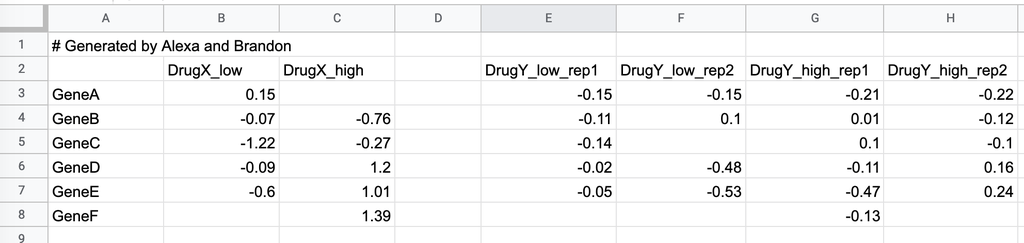

# Common problems with “raw” data files

- Comment lines
- Missing column headers
- Genes are cases rather than variables
- Confounds treatment, dosage, and replicates
- Blank columns – used for visual organization in spreadsheet, but interferes with analysis

# Naively reading the data produces poor results

```r
messy <- read_csv("~/Desktop/small-messy-data.csv")
```

| # Generated by Alexa and Brandon |
| --- |
| ,DrugX_low,DrugX_high,,DrugY_low_rep1,DrugY_low_rep2,DrugY_high_rep1,DrugY_high_rep2 |
| GeneA,0.15,,,-0.15,-0.15,-0.21,-0.22 |
| GeneB,-0.07,-0.76,,-0.11,0.1,0.01,-0.12 |
| GeneC,-1.22,-0.27,,-0.14,,0.1,-0.1 |
| GeneD,-0.09,1.2,,-0.02,-0.48,-0.11,0.16 |
| GeneE,-0.6,1.01,,-0.05,-0.53,-0.47,0.24 |
| GeneF |
| ,1.39 |
| , |
| ,-0.13 |

# Explore options of your reader function(s)

Example: filtering comment lines

```r
messy <- read_csv("~/Desktop/small-messy-data.csv", comment="#")
```

| …1 | DrugX_low | DrugX_high | …4 | DrugY_low_rep1 | DrugY_low_rep2 | DrugY_high_rep1 | DrugY_high_rep2 |
| --- | --- | --- | --- | --- | --- | --- | --- |
| GeneA | 0.15 | NA | NA | -0.15 | -0.15 | -0.21 | -0.22 |
| GeneB | -0.07 | -0.76 | NA | -0.11 | 0.10 | 0.01 | -0.12 |
| GeneC | -1.22 | -0.27 | NA | -0.14 | NA | 0.10 | -0.10 |
| GeneD | -0.09 | 1.20 | NA | -0.02 | -0.48 | -0.11 | 0.16 |
| GeneE | -0.60 | 1.01 | NA | -0.05 | -0.53 | -0.47 | 0.24 |
| GeneF | NA | 1.39 | NA | NA | NA | -0.13 | NA |

# Renaming columns using dplyr::rename

```r
messy <-
  messy %>%
  rename(Gene = "...1")
```

| Gene | DrugX_low | DrugX_high | …4 | DrugY_low_rep1 | DrugY_low_rep2 | DrugY_high_rep1 | DrugY_high_rep2 |
| --- | --- | --- | --- | --- | --- | --- | --- |
| GeneA | 0.15 | NA | NA | -0.15 | -0.15 | -0.21 | -0.22 |
| GeneB | -0.07 | -0.76 | NA | -0.11 | 0.10 | 0.01 | -0.12 |
| GeneC | -1.22 | -0.27 | NA | -0.14 | NA | 0.10 | -0.10 |
| GeneD | -0.09 | 1.20 | NA | -0.02 | -0.48 | -0.11 | 0.16 |
| GeneE | -0.60 | 1.01 | NA | -0.05 | -0.53 | -0.47 | 0.24 |
| GeneF | NA | 1.39 | NA | NA | NA | -0.13 | NA |

# Dropping columns using select

```r
messy %>%
  select(-"...4")
```

| Gene | DrugX_low | DrugX_high | DrugY_low_rep1 | DrugY_low_rep2 | DrugY_high_rep1 | DrugY_high_rep2 |
| --- | --- | --- | --- | --- | --- | --- |
| GeneA | 0.15 | NA | -0.15 | -0.15 | -0.21 | -0.22 |
| GeneB | -0.07 | -0.76 | -0.11 | 0.10 | 0.01 | -0.12 |
| GeneC | -1.22 | -0.27 | -0.14 | NA | 0.10 | -0.10 |
| GeneD | -0.09 | 1.20 | -0.02 | -0.48 | -0.11 | 0.16 |
| GeneE | -0.60 | 1.01 | -0.05 | -0.53 | -0.47 | 0.24 |
| GeneF | NA | 1.39 | NA | NA | -0.13 | NA |

# Dropping columns using select and where

If you had many columns it might not be feasible to specify the names directly. The `where` helper function can be used to specify a function to determine column selection.

```r
messy <-
  messy %>%
  select(-where( function(x) all(is.na(x)) ))
```

| Gene | DrugX_low | DrugX_high | DrugY_low_rep1 | DrugY_low_rep2 | DrugY_high_rep1 | DrugY_high_rep2 |
| --- | --- | --- | --- | --- | --- | --- |
| GeneA | 0.15 | NA | -0.15 | -0.15 | -0.21 | -0.22 |
| GeneB | -0.07 | -0.76 | -0.11 | 0.10 | 0.01 | -0.12 |
| GeneC | -1.22 | -0.27 | -0.14 | NA | 0.10 | -0.10 |
| GeneD | -0.09 | 1.20 | -0.02 | -0.48 | -0.11 | 0.16 |
| GeneE | -0.60 | 1.01 | -0.05 | -0.53 | -0.47 | 0.24 |
| GeneF | NA | 1.39 | NA | NA | -0.13 | NA |

# Reshaping a data frame using pivoting

`tidyr::pivot_longer`:

```r
long_messy <-
  messy %>%
  pivot_longer(-Gene, names_to="Drug_Dosage_Rep", values_to="Expression")
```

| Gene | Drug_Dosage_Rep | Expression |
| --- | --- | --- |
| GeneA | DrugX_low | 0.15 |
| GeneA | DrugX_high | NA |
| GeneA | DrugY_low_rep1 | -0.15 |
| GeneA | DrugY_low_rep2 | -0.15 |
| GeneA | DrugY_high_rep1 | -0.21 |
| GeneA | DrugY_high_rep2 | -0.22 |
| GeneB | DrugX_low | -0.07 |
| GeneB | DrugX_high | -0.76 |
| GeneB | DrugY_low_rep1 | -0.11 |
| GeneB | DrugY_low_rep2 | 0.10 |

# Extract a column in multiple columns

```r
split_long_messy <-
  long_messy %>%
  separate("Drug_Dosage_Rep", into=c("Drug", "Dosage", "Replicate"), sep="_")
```

| Gene | Drug | Dosage | Replicate | Expression |
| --- | --- | --- | --- | --- |
| GeneA | DrugX | low | NA | 0.15 |
| GeneA | DrugX | high | NA | NA |
| GeneA | DrugY | low | rep1 | -0.15 |
| GeneA | DrugY | low | rep2 | -0.15 |
| GeneA | DrugY | high | rep1 | -0.21 |
| GeneA | DrugY | high | rep2 | -0.22 |
| GeneB | DrugX | low | NA | -0.07 |
| GeneB | DrugX | high | NA | -0.76 |
| GeneB | DrugY | low | rep1 | -0.11 |
| GeneB | DrugY | low | rep2 | 0.10 |

# Filling missing data

`tidyr::fill` and `tidyr::replace_na`

```r
tidy_data <-
  split_long_messy %>%
  replace_na(list(Replicate = "rep1"))
```

| Gene | Drug | Dosage | Replicate | Expression |
| --- | --- | --- | --- | --- |
| GeneA | DrugX | low | rep1 | 0.15 |
| GeneA | DrugX | high | rep1 | NA |
| GeneA | DrugY | low | rep1 | -0.15 |
| GeneA | DrugY | low | rep2 | -0.15 |
| GeneA | DrugY | high | rep1 | -0.21 |
| GeneA | DrugY | high | rep2 | -0.22 |
| GeneB | DrugX | low | rep1 | -0.07 |
| GeneB | DrugX | high | rep1 | -0.76 |
| GeneB | DrugY | low | rep1 | -0.11 |
| GeneB | DrugY | low | rep2 | 0.10 |

# Tidy data enables complex summaries

```r
tidy_summary <-
  tidy_data %>%
  group_by(Gene, Drug, Dosage) %>%
  summarize(Mean_Expression = mean(Expression, na.rm=TRUE))
```

| Gene | Drug | Dosage | Mean_Expression |
| --- | --- | --- | --- |
| GeneA | DrugX | high | NaN |
| GeneA | DrugX | low | 0.150 |
| GeneA | DrugY | high | -0.215 |
| GeneA | DrugY | low | -0.150 |
| GeneB | DrugX | high | -0.760 |
| GeneB | DrugX | low | -0.070 |
| GeneB | DrugY | high | -0.055 |
| GeneB | DrugY | low | -0.005 |
| GeneC | DrugX | high | -0.270 |
| GeneC | DrugX | low | -1.220 |

# Tidy data enables complex plotting

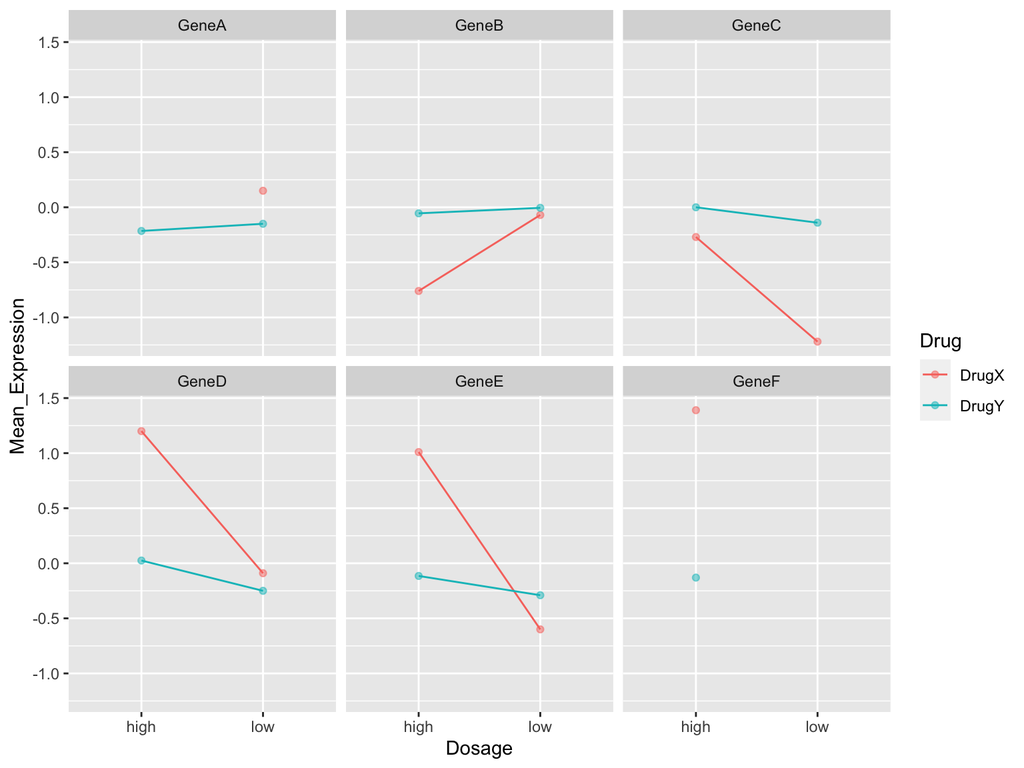

```r
tidy_summary %>%
  ggplot(aes(x = Dosage, y = Mean_Expression, color=Drug)) +
  geom_point(alpha=0.5) +
  geom_line(aes(group=Drug)) +
  facet_wrap(~Gene)
```

# Summary and raw values as different ggplot layers

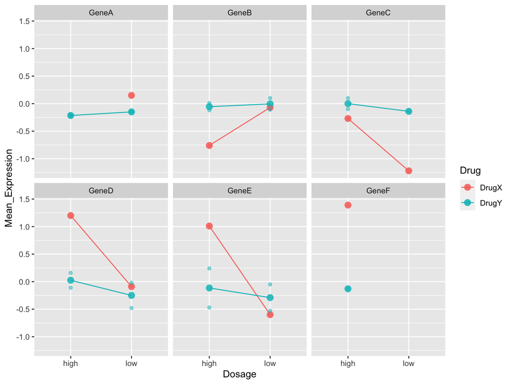

```r
tidy_summary %>%
  ggplot(aes(x = Dosage, y = Mean_Expression, color=Drug)) +
  geom_point(alpha=0.85, size=3) +
  geom_line(aes(group=Drug)) +
  geom_point(data=tidy_data,
             mapping=aes(x = Dosage, y = Expression, color=Drug),
             alpha = 0.5, size = 1.5,
             inherit.aes = FALSE) +
  facet_wrap(~Gene)
```

# Widening

`tidyr::pivot_wider` spreads data across columns:

```r
tidy_summary %>%
  pivot_wider(names_from = Gene, values_from = Mean_Expression)
```

| Drug | Dosage | GeneA | GeneB | GeneC | GeneD | GeneE | GeneF |
| --- | --- | --- | --- | --- | --- | --- | --- |
| DrugX | high | NaN | -0.760 | -0.27 | 1.200 | 1.010 | 1.39 |
| DrugX | low | 0.150 | -0.070 | -1.22 | -0.090 | -0.600 | NaN |
| DrugY | high | -0.215 | -0.055 | 0.00 | 0.025 | -0.115 | -0.13 |
| DrugY | low | -0.150 | -0.005 | -0.14 | -0.250 | -0.290 | NaN |

```r
tidy_summary %>%
  ungroup() %>%  # ungroup important here
  pivot_wider(names_from = Gene, values_from = Mean_Expression) %>%
  select(!c(Drug,Dosage,GeneF)) %>%
  cor(use = "pairwise.complete.obs" )
```

|  | GeneA | GeneB | GeneC | GeneD | GeneE |
| --- | --- | --- | --- | --- | --- |
| GeneA | 1.0000000 | -0.5464173 | -0.9980371 | -0.0734459 | -0.9807466 |
| GeneB | -0.5464173 | 1.0000000 | -0.1197536 | -0.9929120 | -0.9472035 |
| GeneC | -0.9980371 | -0.1197536 | 1.0000000 | 0.1652294 | 0.4313106 |
| GeneD | -0.0734459 | -0.9929120 | 0.1652294 | 1.0000000 | 0.9572841 |
| GeneE | -0.9807466 | -0.9472035 | 0.4313106 | 0.9572841 | 1.0000000 |